# Final Project Report

Omkar Purandare

April 24, 2020

# Set Up

```r
# load necessary packages
library(tidyverse)
library(mosaic)
library(rvest)
library(tidyr)
library(dplyr)
library(lubridate)
library(DataComputing)
```

# Guiding Question

## Question

What is the relationship between languages spoken in a country to the respective social and economic development of the country in 2014?

## Why this Topic

Growing up both in India and America as a student, I grew up speaking 4 languages and was in an environment where some of my peers spoke upwards of 6-10 languages due to the language diversity within India. The concepts of language had always intrigued me growing up, it was a form of social currency.

On coming to Penn State and back to America after 10 years I came to realize that most American barely speak more than 2 languages. While being a Major industrial hub, and economic leader i wondered how does the Languages spoken in a country affect its economy and society.

**Hence I’ve chosen this topic!**

## Becoming acquainted with your data sources

The data sources we will be using for this project are divided into 2 categories:

- Primary Data
- Other Data Sources

**Primary Data**

The Primary data sources we will use are:

- List of Number of languages by country from Wikipedia [(link here)](https://en.wikipedia.org/wiki/Number_of_languages_by_country)
  - This data is found on Wikipedia and it controlled by the Wikimedia Foundation Inc
  - This data is collected by the Wikimedia Foundation from bunch of sources as the respective governments webpage, new articles etc. The data is collected for open source knowledge for the population reading this webpage.
  - This page was last updated on March 27th 2020.
  - The variables I mean to use in their project are Country or Territory and Established
  - On a whole it has 243 cases and 9 variables

Here’s the data imported into this R notebook

```r
# CODE
page <- "https://en.wikipedia.org/wiki/Number_of_languages_by_country"
tableList <- page %>%
  read_html() %>%
  html_nodes(css = "table") %>%
  html_table(fill = TRUE)



Languages <- tableList[[1]]
```

Here’s a glimpse at the Data Table

```r
# CODE
Languages%>% glimpse()
```

```
Observations: 243
Variables: 9
$ Rank                         <chr> "Rank", "1", "2", "3", "4", "5", "6"…
$ `Country or territory`       <chr> "Country or territory", "Papua New G…
$ `Number of living languages` <chr> "Established", "840", "707", "517", …
$ `Number of living languages` <chr> "Immigrant", "0", "3", "7", "6", "3"…
$ `Number of living languages` <chr> "Total", "840", "710", "524", "453",…
$ `Number of living languages` <chr> "Percent[note 1]", "11.81", "9.98", …
$ `Number of speakers`         <chr> "Total", "4,213,381", "222,191,197",…
$ `Number of speakers`         <chr> "Mean", "5,040", "315,165", "348,225…
$ `Number of speakers`         <chr> "Median", "1,315", "3,500", "14,000"…
```

```r
Languages
```

| Rank | Country or territory | Number of living languages | Number of living languages | Number of living languages | Number of living languages | Number of speakers | Number of speakers | Number of speakers |
| --- | --- | --- | --- | --- | --- | --- | --- | --- |
| Rank | Country or territory | Established | Immigrant | Total | Percent[note 1] | Total | Mean | Median |
| 1 | Papua New Guinea | 840 | 0 | 840 | 11.81 | 4,213,381 | 5,040 | 1,315 |
| 2 | Indonesia | 707 | 3 | 710 | 9.98 | 222,191,197 | 315,165 | 3,500 |
| 3 | Nigeria | 517 | 7 | 524 | 7.37 | 163,317,444 | 348,225 | 14,000 |
| 4 | India | 447 | 6 | 453 | 6.37 | 1,257,421,714 | 2,924,237 | 35,000 |
| 5 | China (mainland only) | 302 | 3 | 305 | 4.29 | 1,319,419,348 | 4,472,608 | 27,700 |
| 6 | Mexico | 287 | 5 | 292 | 4.11 | 125,535,200 | 435,886 | 4,730 |
| 7 | Cameroon | 274 | 1 | 275 | 3.87 | 10,228,065 | 38,451 | 10,000 |
| 8 | Australia | 226 | 93 | 319 | 4.49 | 22,693,732 | 72,504 | 10 |
| 9 | United States | 219 | 116 | 335 | 4.71 | 326,756,719 | 999,256 | 12 |

[output cut: 233 more lines]

**Other Data Sources**

The Other data sources we will use are:

- CountryData
  - This data is from the R package DataComputing
  - This data is collected by the Central Intelligence Agency in USA. The data is collected for open source knowledge for the population reading this webpage and their own cataloging.
  - This page was last updated in 2014.
  - The variables I mean to use in their project are county and GDP,GDPgrowth, obesity, netUsers, pop, growth
  - On a whole it has 256 cases and 76 variables

Here’s the data imported into this R notebook

```r
# CODE
CountryData
```

| country | area | pop | growth | birth | death | migr | maternal | infant | life | fert | health | HIVrate | HIVpeople | HIVdeath | obesity | underweight | educ | unemploymentYouth | GDP | GDPgrowth | GDPcapita | saving | indProd | labor | unemployment | family | tax | budget | debt | … |
| --- | --- | --- | --- | --- | --- | --- | --- | --- | --- | --- | --- | --- | --- | --- | --- | --- | --- | --- | --- | --- | --- | --- | --- | --- | --- | --- | --- | --- | --- | --- |
| Afghanistan | 652230 | 31822848 | 2.29 | 38.84 | 14.12 | -1.83 | 460 | 117.23 | 50.49 | 5.43 | 9.6 | 0.10 | 4300 | 300 | 2.2 | 32.9 | NA | NA | 4.530e+10 | 3.1 | 1100 | NA | NA | 7512000 | 35.0 | NA | 11.3 | -8.7 | NA | … |
| Akrotiri | 123 | 15700 | NA | NA | NA | NA | NA | NA | NA | NA | NA | NA | NA | NA | NA | NA | NA | NA | NA | NA | NA | NA | NA | NA | NA | NA | NA | NA | NA | … |
| Albania | 28748 | 3020209 | 0.30 | 12.73 | 6.47 | -3.31 | 27 | 13.19 | 77.96 | 1.50 | 6.3 | NA | NA | NA | 21.3 | 6.3 | 3.3 | 22.5 | 2.834e+10 | 0.7 | 10700 | 14.1 | 3.1 | 1098000 | 16.9 | 34.5 | 24.0 | -6.1 | 70.5 | … |
| Algeria | 2381741 | 38813722 | 1.88 | 23.99 | 4.31 | -0.93 | 97 | 21.76 | 76.39 | 2.78 | 3.9 | 0.10 | 18000 | 1000 | 16.0 | 3.7 | 4.3 | 28.4 | 2.847e+11 | 3.1 | 7500 | 45.5 | 2.5 | 11150000 | 10.3 | 35.3 | 37.3 | -2.3 | 13.2 | … |
| American Samoa | 199 | 54517 | -0.35 | 22.87 | 4.68 | -21.64 | NA | 8.92 | 74.91 | 2.98 | NA | NA | NA | NA | 74.6 | NA | NA | NA | 5.753e+08 | 3.0 | 8000 | NA | NA | 17630 | 29.8 | NA | 33.6 | -6.1 | NA | … |
| Andorra | 468 | 85458 | 0.17 | 8.48 | 6.82 | 0.00 | NA | 3.69 | 82.65 | 1.38 | 7.2 | NA | NA | NA | 25.2 | NA | NA | NA | 3.163e+09 | -1.6 | 37200 | NA | NA | 36060 | 4.0 | NA | 21.4 | -0.3 | 41.1 | … |
| Angola | 1246700 | 19088106 | 2.78 | 38.97 | 11.67 | 0.47 | 450 | 79.99 | 55.29 | 5.43 | 3.5 | 2.30 | 248800 | 12600 | 6.4 | 15.6 | 3.5 | NA | 1.318e+11 | 5.6 | 6300 | 19.1 | 5.5 | 9018000 | NA | NA | 42.5 | 3.4 | 14.7 | … |
| Anguilla | 91 | 16086 | 2.06 | 12.68 | 4.54 | 12.43 | NA | 3.40 | 81.20 | 1.75 | NA | NA | NA | NA | NA | NA | 2.8 | NA | 1.754e+08 | -8.5 | 12200 | NA | 2.0 | 6049 | 8.0 | NA | 39.6 | -5.0 | 20.0 | … |
| Antarctica | NA | NA | NA | NA | NA | NA | NA | NA | NA | NA | NA | NA | NA | NA | NA | NA | NA | NA | NA | NA | NA | NA | NA | NA | NA | NA | NA | NA | NA | … |
| Antigua and Barbuda | 443 | 91295 | 1.25 | 15.94 | 5.70 | 2.23 | NA | 13.29 | 76.12 | 2.03 | 5.9 | NA | NA | NA | 25.6 | NA | 2.4 | 19.9 | 1.610e+09 | 1.7 | 18400 | 18.0 | 1.0 | 30000 | 11.0 | NA | 19.6 | -0.8 | 89.0 | … |

[output cut: 246 more lines]

Here’s a glimpse at the Data Table

```r
# CODE
CountryData %>% glimpse()
```

```
Observations: 256
Variables: 76
$ country           <chr> "Afghanistan", "Akrotiri", "Albania", "Algeria"…
$ area              <dbl> 652230, 123, 28748, 2381741, 199, 468, 1246700,…
$ pop               <dbl> 31822848, 15700, 3020209, 38813722, 54517, 8545…
$ growth            <dbl> 2.29, NA, 0.30, 1.88, -0.35, 0.17, 2.78, 2.06, …
$ birth             <dbl> 38.84, NA, 12.73, 23.99, 22.87, 8.48, 38.97, 12…
$ death             <dbl> 14.12, NA, 6.47, 4.31, 4.68, 6.82, 11.67, 4.54,…
$ migr              <dbl> -1.83, NA, -3.31, -0.93, -21.64, 0.00, 0.47, 12…
$ maternal          <dbl> 460, NA, 27, 97, NA, NA, 450, NA, NA, NA, 77, 3…
$ infant            <dbl> 117.23, NA, 13.19, 21.76, 8.92, 3.69, 79.99, 3.…
$ life              <dbl> 50.49, NA, 77.96, 76.39, 74.91, 82.65, 55.29, 8…
$ fert              <dbl> 5.43, NA, 1.50, 2.78, 2.98, 1.38, 5.43, 1.75, N…
$ health            <dbl> 9.6, NA, 6.3, 3.9, NA, 7.2, 3.5, NA, NA, 5.9, 8…
$ HIVrate           <dbl> 0.1, NA, NA, 0.1, NA, NA, 2.3, NA, NA, NA, 0.4,…
```

[output cut: 63 more lines]

## Explore intuition related to the research question

Data Wrangling for Languages

The renaming of variables in the Languages Data Frame

```r
# CODE
names(Languages)[c(2,3,4,5,6,7,8,9)] <- c("country", "count_lang","immigrant","total","percent","t", "mean", "median")
```

Since we will only need to be using the number of languages per country information from the Languages Data Frame, we transform the database to accommodate our requirements

```r
# CODE
Languages <-
  Languages %>%
  filter(row_number() > 1) %>%
  select(country,count_lang) %>%
  mutate(count_lang = as.numeric(count_lang))
```

**Joining both Data sets**

Creation of a Hypothesis Data Frame that we will use for analysis for the rest of the project by joining the Languages and Country Data Data Frame with the respective identifiers we wish to analyze (eg. GDP growth, netUsers etc.)

```r
# CODE
Hypo <-
  Languages %>%
  left_join(CountryData %>% select(country,GDP,GDPgrowth, obesity,netUsers,pop,growth), by = c("country" = "country"))

Hypo
```

| country | count_lang | GDP | GDPgrowth | obesity | netUsers | pop | growth |
| --- | --- | --- | --- | --- | --- | --- | --- |
| Papua New Guinea | 840 | 1.996e+10 | 5.4 | 16.2 | 125000 | 6552730 | 1.84 |
| Indonesia | 707 | 1.285e+12 | 5.3 | 4.8 | 20000000 | 253609643 | 0.95 |
| Nigeria | 517 | 4.785e+11 | 6.2 | 6.5 | 43989000 | 177155754 | 2.47 |
| India | 447 | 4.990e+12 | 3.2 | 1.9 | 61338000 | 1236344631 | 1.25 |
| China (mainland only) | 302 | NA | NA | NA | NA | NA | NA |
| Mexico | 287 | 1.845e+12 | 1.2 | 32.1 | 31020000 | 120286655 | 1.21 |
| Cameroon | 274 | 5.316e+10 | 4.6 | 10.3 | 749600 | 23130708 | 2.60 |
| Australia | 226 | 9.983e+11 | 2.5 | 26.8 | 15810000 | 22507617 | 1.09 |
| United States | 219 | 1.672e+13 | 1.6 | 33.0 | 245000000 | 318892103 | 0.77 |
| Brazil | 217 | 2.416e+12 | 2.3 | 18.8 | 75982000 | 202656788 | 0.80 |

[output cut: 232 more lines]

## Country Starting from A-F and their Languages Spoken

Just as a test we will just see the number of langueges spoken with countires starting with letters A- F

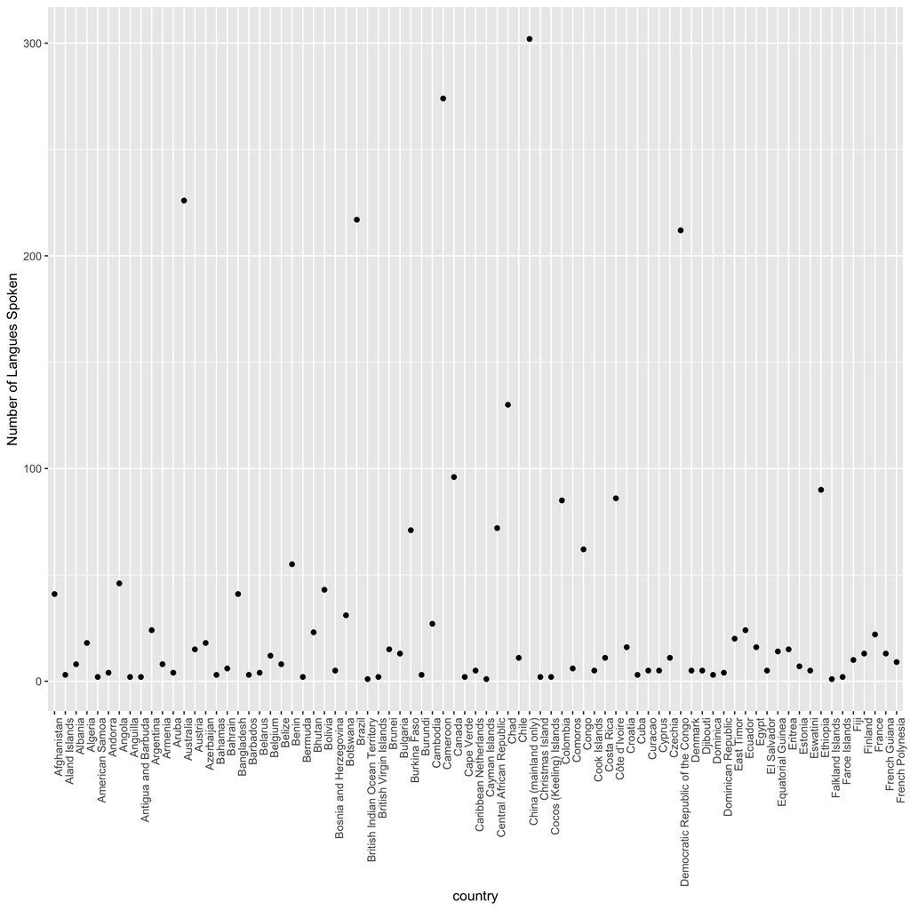

```r
# CODE
# Scatterplot Graph
Hypo %>%
  filter(grepl("^[ABCDEF]", country, ignore.case = TRUE)) %>%
  ggplot(aes(x=country, y=count_lang)) + geom_point() +
  theme(axis.text.x = element_text(angle = 90, hjust = 1)) +
  labs(y = "Number of Langues Spoken")
```

## Country Starting from G-0 and their Languages Spoken

Just as a test we will just see the number of langueges spoken with countires starting with letters G-0. This time lets use density graph

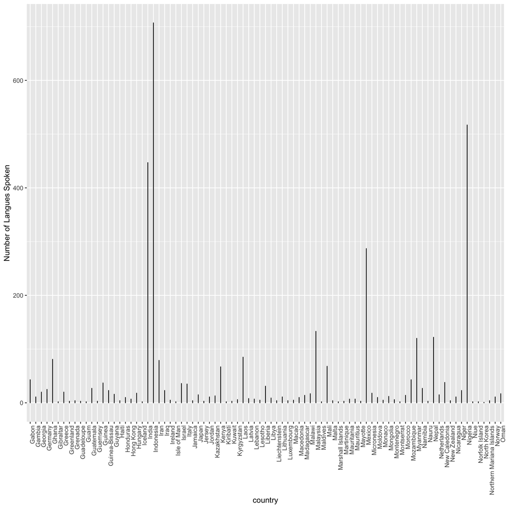

```r
# CODE
# Density Graph
Hypo %>%
  filter(grepl("^[GHIJKLMNO]", country, ignore.case = TRUE)) %>%
  ggplot(aes(x=country, y=count_lang)) + geom_density(stat="identity", position = "stack") +
  theme(axis.text.x = element_text(angle = 90, hjust = 1)) +
  labs(y = "Number of Langues Spoken")
```

## Analylitcal Visualization

### Relationship between Languages spoken and GDP Growth

Using Graphics to show some informative plots and summary statistics to see if there is a relationship between languages spoken in country and growth of countries GDP

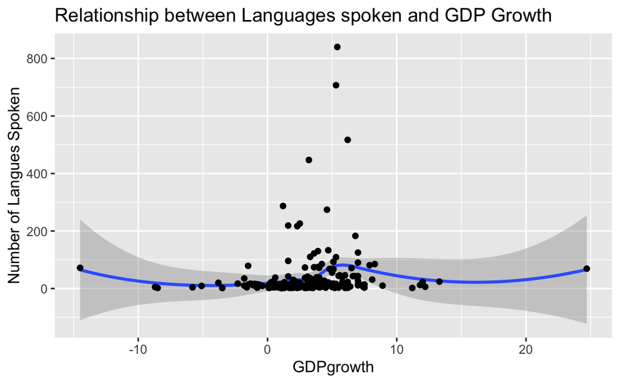

```r
# CODE
# Scatterplot Graph
Hypo %>%
  mutate(country = reorder(country, count_lang)) %>%
  ggplot(aes(x=GDPgrowth, y= count_lang)) + stat_smooth(method = 'loess') + geom_point() +
  ggtitle("Relationship between Languages spoken and GDP Growth") +
  labs(y = "Number of Langues Spoken")
```

**Seeing the confidence interval being large we can see there is not much of a relationship between the two variables**

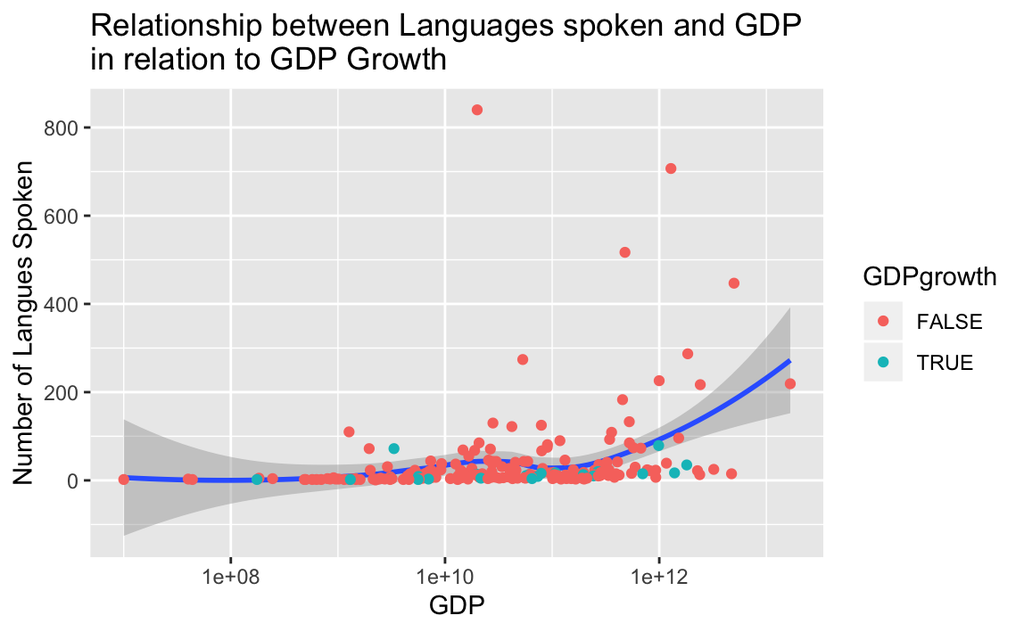

```r
# CODE
# Scatterplot Graph
Hypo %>%
  mutate(country = reorder(country, count_lang)) %>%
  mutate( GDPgrowth = GDPgrowth <0) %>% # Check for all Psitive Growth countries
  drop_na(GDPgrowth) %>%
  ggplot(aes(x=GDP, y= count_lang)) + stat_smooth(method = 'loess') + geom_point(aes(color =GDPgrowth)) + scale_x_log10() +
  ggtitle("Relationship between Languages spoken and GDP\nin relation to GDP Growth") +
  labs(y = "Number of Langues Spoken")
```

### Relationship between Languages spoken and Obesity rate

Using Graphics to show some informative plots and summary statistics to see if there is a relationship between languages spoken in country and obesity of country

[figure not shown]

```r
# CODE
# Density Graph
Hypo %>%
  mutate(country = reorder(country, count_lang)) %>%
  mutate(obesity_interval = mosaic::ntiles(obesity, n = 4, format = "interval")) %>%
  ggplot(aes(x=obesity_interval)) + geom_density(stat = "density",
  position = "identity",adjust = 0.4, aes(fill = obesity_interval)) +
  ggtitle("Relationship between Languages spoken and Obesity rate")
```

### Relationship between Languages spoken and Internet Users

Using Graphics to show some informative plots and summary statistics to see if there is a relationship between languages spoken in country and internet users of country

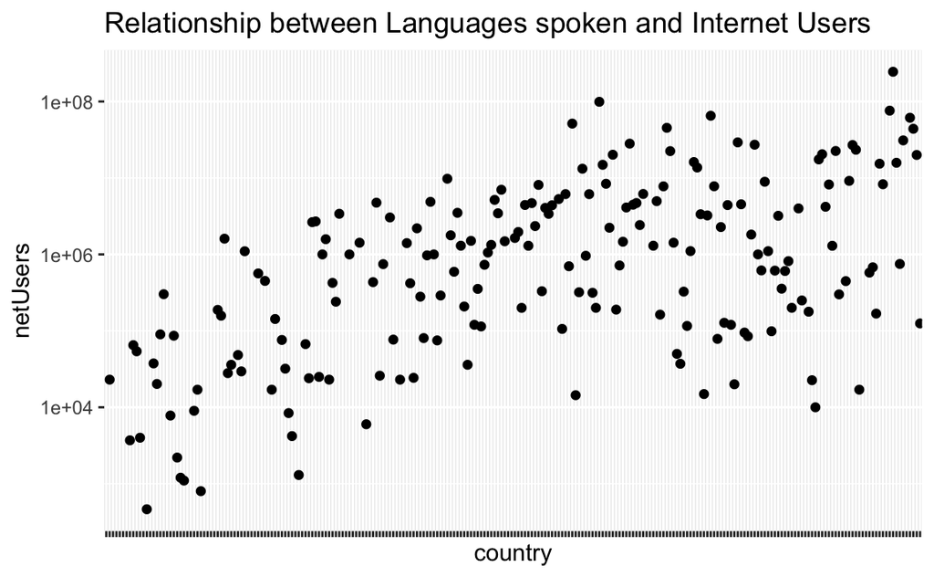

```r
# CODE
# Scatterplot Graph
Hypo %>%
  mutate(country = reorder(country, count_lang)) %>%
  ggplot(aes(x=country, y= netUsers)) +
  stat_smooth(aes(),method='loess') +
  geom_point() +
  scale_y_log10() +
  theme(axis.text.x = element_blank()) +
  ggtitle("Relationship between Languages spoken and Internet Users")
```

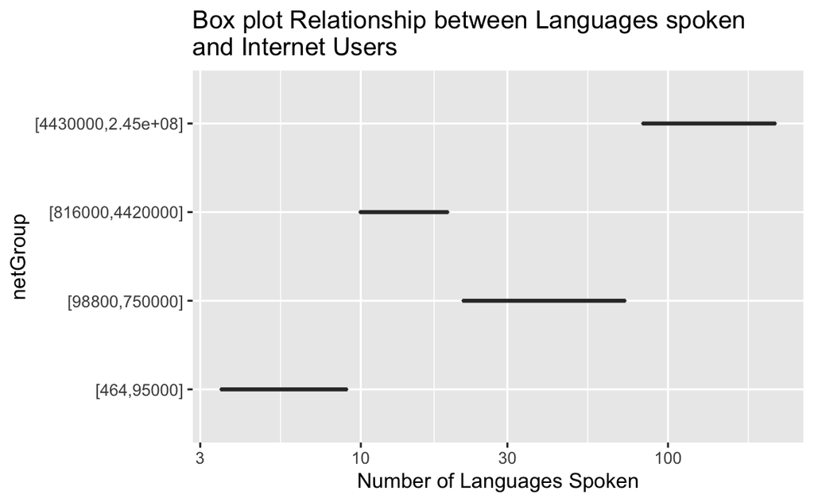

```r
# CODE
# Boxplot Graph
Hypo %>%
  mutate(country = reorder(country, count_lang)) %>%
  mutate(netGroup = mosaic::ntiles(netUsers, n = 4, format = "interval")) %>%
  drop_na(netGroup) %>%
  ggplot(aes(x=count_lang, y=netGroup)) +
  geom_boxplot() + scale_x_log10() +
  ggtitle("Box plot Relationship between Languages spoken\nand Internet Users") +
  labs(x = "Number of Languages Spoken" )
```

### Relationship between Languages spoken and Population

Using Graphics to show some informative plots and summary statistics to see if there is a relationship between languages spoken in country and Population of the country

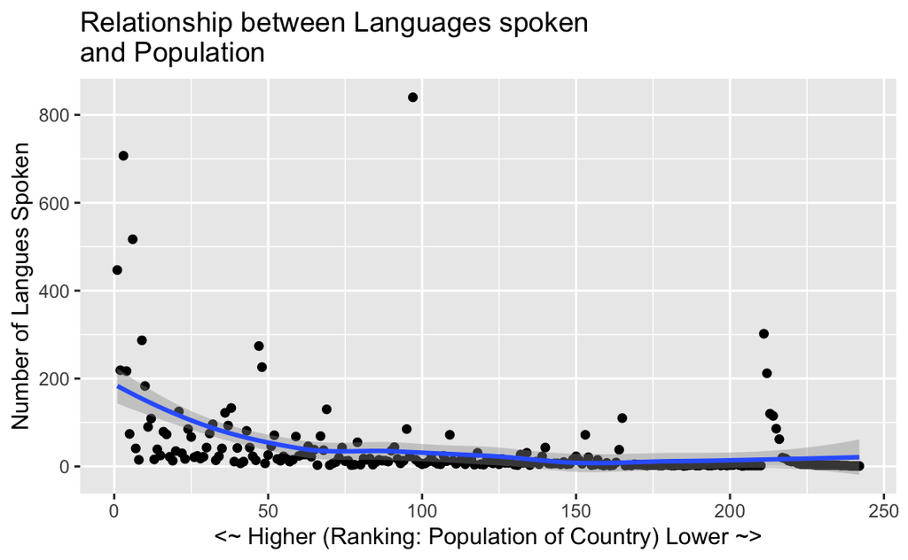

```r
# CODE
# Scatterplot Graph
Hypo %>%
  select(country, count_lang,pop) %>%
  mutate(country = reorder(country, count_lang)) %>%
  mutate(the_rank = rank(-pop)) %>% # creating a variable to rank the poplations
  ggplot(aes(x = the_rank, y= count_lang)) + geom_point() + stat_smooth() +
  ggtitle("Relationship between Languages spoken\nand Population") +
  labs(x = "<~ Higher (Ranking: Population of Country) Lower ~>") +
  labs(y = "Number of Langues Spoken")
```

Now what would this look like for countries where their population increases or decreases per yer?

### Relationship between Languages spoken and Population in relation to Population Growth

Using Graphics to show some informative plots and summary statistics to see if there is a relationship between languages spoken in country and Population growth of the country

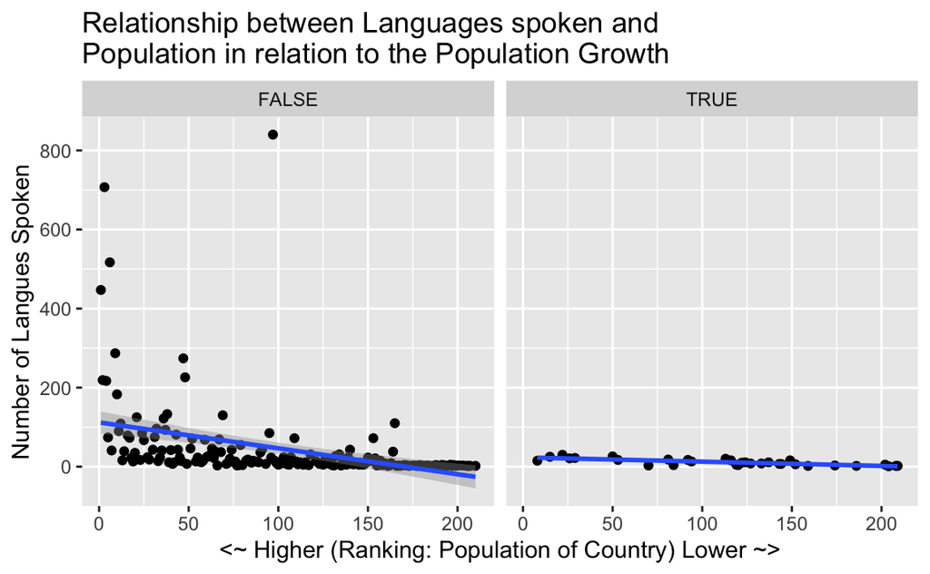

```r
Hypo %>%
  select(country, count_lang,pop, growth) %>%
  mutate(the_rank = rank(-pop)) %>%
  mutate(country = reorder(country, count_lang)) %>%
  mutate( growth = growth <0) %>% # Check for all Psitive Growth countries
  drop_na(growth) %>%
  ggplot(aes(x = the_rank, y= count_lang))+
  geom_point() + stat_smooth(method = lm) +
  facet_wrap(~growth)+
  ggtitle("Relationship between Languages spoken and\nPopulation in relation to the Population Growth") +
  labs(x = "<~ Higher (Ranking: Population of Country) Lower ~>") +
  labs(y = "Number of Langues Spoken")
```

# Technical challenges encountered during the investigation

In doing these analysis some challenges I encountered were:

- Acquiring Suitable Data for the Project

This topic was very broad and the data that could be used for analysis innumerate. The challenge was to find trustworthy data which is also accessible to the user. In researching online, most data had to be paid for and open source data links were years behind, hence I decided to use the R package Data Frame CountryData itself

- Getting the data in Glyph ready Format

Most of the Data was Tidy but not in a Glyph ready for in order to do analysis so a majority of the coding work done in the chunk is there to transform the data to be suitable for analysis.

# Conclusion

Therefore the Percentage of Identifiers with a Relationship

$P = {\frac{3}{6}*100}= 50\%$

Therefore the Percentage of Identifiers with no a Relationship

$P = {\frac{3}{6}*100}= 50\%$